# Рынок заведений общественного питания Москвы

# Описание проекта и данных

## Описание проекта

Инвесторы из фонда `«Shut Up and Take My Money»` решили попробовать себя в новой области и открыть заведение общественного питания в Москве. Заказчики ещё не знают, что это будет за место: кафе, ресторан, пиццерия, паб или бар, — и какими будут расположение, меню и цены.

Для этого они просят нас подготовить исследование рынка Москвы в целом, а также рынка кофеен (дать рекомендации для его успешного открытия) интересные особенности и презентовать полученные результаты, которые в будущем помогут в выборе подходящего инвесторам места.

Для ответа на этот вопрос, нам нужно будет проделать следующие шаги:

1. Подготовить и преодработать данные;
2. Провести необходимый анализ, произведя расчеты и построив графики для ответа на поставленный вопрос от инвесторов;
3. Провести исследование рынка кофеен и дать рекомендации;
4. Сделать выводы и подготовить презентацию ([ссылка](https://disk.yandex.ru/i/Q1SjomSmV8RFCg)) с результатами исследования.

## Описание данных

В нашем распоряжении датасет с заведениями общественного питания Москвы, составленный на основе данных сервисов Яндекс Карты и Яндекс Бизнес на лето 2022 года.

**Структура данных датасета:**

- `name` — название заведения;
- `address` — адрес заведения;
- `category` — категория заведения, например «кафе», «пиццерия» или «кофейня»;
- `hours` — информация о днях и часах работы;
- `lat` — широта географической точки, в которой находится заведение;
- `lng` — долгота географической точки, в которой находится заведение;
- `rating` — рейтинг заведения по оценкам пользователей в Яндекс Картах (высшая оценка — 5.0);
- `price` — категория цен в заведении, например «средние», «ниже среднего», «выше среднего» и так далее;
- `avg_bill` — строка, которая хранит среднюю стоимость заказа в виде диапазона, например:

```
- «Средний счёт: 1000–1500 ₽»;
- «Цена чашки капучино: 130–220 ₽»;
- «Цена бокала пива: 400–600 ₽», и так далее;
```

- `middle_avg_bill` — число с оценкой среднего чека, которое указано только для значений из столбца avg_bill, начинающихся с подстроки «Средний счёт»:

```
- Если в строке указан ценовой диапазон из двух значений, в столбец войдёт медиана этих двух значений.
- Если в строке указано одно число — цена без диапазона, то в столбец войдёт это число.
- Если значения нет или оно не начинается с подстроки «Средний счёт», то в столбец ничего не войдёт.
```

- `middle_coffee_cup` — число с оценкой одной чашки капучино, которое указано только для значений из столбца avg_bill, начинающихся с подстроки «Цена одной чашки капучино»:
- Если в строке указан ценовой диапазон из двух значений, в столбец войдёт медиана этих двух значений.
- Если в строке указано одно число — цена без диапазона, то в столбец войдёт это число.
- Если значения нет или оно не начинается с подстроки «Цена одной чашки капучино», то в столбец ничего не войдёт.
- `chain` — число, выраженное 0 или 1, которое показывает, является ли заведение сетевым (для маленьких сетей могут встречаться ошибки):

```
- 0 — заведение не является сетевым
- 1 — заведение является сетевым
```

- `district` — административный район, в котором находится заведение, например Центральный административный округ;
- `seats` — количество посадочных мест.

# Обзор и предобработка данных

## Обзор данных

```python
# Имптортируем необходимые библиотеки

import pandas as pd
import numpy as np
from folium import Map, Marker, Choropleth
from folium.plugins import MarkerCluster
import json
import matplotlib.pyplot as plt
import seaborn as sns
from plotly import express as px
from plotly import graph_objects as go
from plotly.subplots import make_subplots
```

```python
# Для удобства отобразим все колонки таблицы и изменим их ширину

pd.set_option('display.max_columns', None)
pd.set_option('max_colwidth', None)
```

```python
# Прочитаем и запишем в переменную данные из датафрейма
df = pd.read_csv('moscow_places.csv')
```

```python
# Создадим функцию для обзора данных: выведем первые и последние 5 строк, общую информацию, количество и процент пропусков,
# кол-во и долю дубликатов и статистические данные по датафрейму.
# Функция на вход будет принимать датафрейм.

def df_review(data):

    # Выведем первые и последние 5 строк из датафрейму
    print('{0:^125}'.format('Обзор данных датасета'))
    display(data)
    print('-'*120)

    # Выведем общую информацию по датафрейму
    print('{0:^125}'.format('Общая информация по датасету'),end='\n\n')
    data.info()
    print('-'*120)

    # Выведем кол-во и процент пропусков в колонках датафрейма
    print('{0:^125}'.format('Количество пропусков и их доля от всех строк в колонке'))
    # Посчитаем кол-во пропусков и их процент от общего числа строк в датафрейме по каждому столбцу
    num_of_nan = data.isnull().sum().to_frame().reset_index().merge \
    (round(data.isnull().mean()*100,2).to_frame().reset_index(), on='index', how='left')
    # Переимунуем названия колонок для удобства и выведем рез-т
    num_of_nan.columns = ['columns','nan_count','nan_ratio']
    num_of_nan['nan_ratio'] = num_of_nan['nan_ratio'].map('{0:.2f}%'.format)
    display(num_of_nan.sort_values(by='nan_count', ascending=False))
    print('-'*120)

    # Посчитаем кол-во и долю явных дубликатов в датафрейме
    print(f'Количество явных дубликатов в датасете: {data.duplicated().sum()}')
    print (f'Доля явных дубликатов в датасете: {round(100*data.duplicated().sum()/data.shape[0],2)}%')
    print('-'*120,end='\n\n')

    # Выведем информацию по статистическим данным датафрейма
    print('{0:^125}'.format('Обзор cтатистических данных по датасету'))
    display(data.describe())
```

```python
# Проведем первичный обзор данных
df_review(df)
```

```
                                                    Обзор данных датасета
```

|  | name | category | address | district | hours | lat | lng | rating | price | avg_bill | middle_avg_bill | middle_coffee_cup | chain | seats |
| --- | --- | --- | --- | --- | --- | --- | --- | --- | --- | --- | --- | --- | --- | --- |
| 0 | WoWфли | кафе | Москва, улица Дыбенко, 7/1 | Северный административный округ | ежедневно, 10:00–22:00 | 55.878494 | 37.478860 | 5.0 | NaN | NaN | NaN | NaN | 0 | NaN |
| 1 | Четыре комнаты | ресторан | Москва, улица Дыбенко, 36, корп. 1 | Северный административный округ | ежедневно, 10:00–22:00 | 55.875801 | 37.484479 | 4.5 | выше среднего | Средний счёт:1500–1600 ₽ | 1550.0 | NaN | 0 | 4.0 |
| 2 | Хазри | кафе | Москва, Клязьминская улица, 15 | Северный административный округ | пн-чт 11:00–02:00; пт,сб 11:00–05:00; вс 11:00–02:00 | 55.889146 | 37.525901 | 4.6 | средние | Средний счёт:от 1000 ₽ | 1000.0 | NaN | 0 | 45.0 |
| 3 | Dormouse Coffee Shop | кофейня | Москва, улица Маршала Федоренко, 12 | Северный административный округ | ежедневно, 09:00–22:00 | 55.881608 | 37.488860 | 5.0 | NaN | Цена чашки капучино:155–185 ₽ | NaN | 170.0 | 0 | NaN |
| 4 | Иль Марко | пиццерия | Москва, Правобережная улица, 1Б | Северный административный округ | ежедневно, 10:00–22:00 | 55.881166 | 37.449357 | 5.0 | средние | Средний счёт:400–600 ₽ | 500.0 | NaN | 1 | 148.0 |
| ... | ... | ... | ... | ... | ... | ... | ... | ... | ... | ... | ... | ... | ... | ... |
| 8401 | Суши Мания | кафе | Москва, Профсоюзная улица, 56 | Юго-Западный административный округ | ежедневно, 09:00–02:00 | 55.670021 | 37.552480 | 4.4 | NaN | NaN | NaN | NaN | 0 | 86.0 |
| 8402 | Миславнес | кафе | Москва, Пролетарский проспект, 19, корп. 1 | Южный административный округ | ежедневно, 08:00–22:00 | 55.640875 | 37.656553 | 4.8 | NaN | NaN | NaN | NaN | 0 | 150.0 |
| 8403 | Самовар | кафе | Москва, Люблинская улица, 112А, стр. 1 | Юго-Восточный административный округ | ежедневно, круглосуточно | 55.648859 | 37.743219 | 3.9 | NaN | Средний счёт:от 150 ₽ | 150.0 | NaN | 0 | 150.0 |
| 8404 | Чайхана Sabr | кафе | Москва, Люблинская улица, 112А, стр. 1 | Юго-Восточный административный округ | ежедневно, круглосуточно | 55.648849 | 37.743222 | 4.2 | NaN | NaN | NaN | NaN | 1 | 150.0 |
| 8405 | Kebab Time | кафе | Москва, Россошанский проезд, 6 | Южный административный округ | ежедневно, круглосуточно | 55.598229 | 37.604702 | 3.9 | NaN | NaN | NaN | NaN | 0 | 12.0 |

8406 rows × 14 columns

```
------------------------------------------------------------------------------------------------------------------------
                                                Общая информация по датасету

<class 'pandas.core.frame.DataFrame'>
RangeIndex: 8406 entries, 0 to 8405
Data columns (total 14 columns):
 #   Column             Non-Null Count  Dtype
---  ------             --------------  -----
 0   name               8406 non-null   object
 1   category           8406 non-null   object
 2   address            8406 non-null   object
 3   district           8406 non-null   object
 4   hours              7870 non-null   object
 5   lat                8406 non-null   float64
 6   lng                8406 non-null   float64
 7   rating             8406 non-null   float64
 8   price              3315 non-null   object
 9   avg_bill           3816 non-null   object
 10  middle_avg_bill    3149 non-null   float64
 11  middle_coffee_cup  535 non-null    float64
 12  chain              8406 non-null   int64
 13  seats              4795 non-null   float64
dtypes: float64(6), int64(1), object(7)
memory usage: 919.5+ KB
------------------------------------------------------------------------------------------------------------------------
                                   Количество пропусков и их доля от всех строк в колонке
```

|  | columns | nan_count | nan_ratio |
| --- | --- | --- | --- |
| 11 | middle_coffee_cup | 7871 | 93.64% |
| 10 | middle_avg_bill | 5257 | 62.54% |
| 8 | price | 5091 | 60.56% |
| 9 | avg_bill | 4590 | 54.60% |
| 13 | seats | 3611 | 42.96% |
| 4 | hours | 536 | 6.38% |
| 0 | name | 0 | 0.00% |
| 1 | category | 0 | 0.00% |
| 2 | address | 0 | 0.00% |
| 3 | district | 0 | 0.00% |
| 5 | lat | 0 | 0.00% |
| 6 | lng | 0 | 0.00% |
| 7 | rating | 0 | 0.00% |
| 12 | chain | 0 | 0.00% |

```
------------------------------------------------------------------------------------------------------------------------
Количество явных дубликатов в датасете: 0
Доля явных дубликатов в датасете: 0.0%
------------------------------------------------------------------------------------------------------------------------

                                           Обзор cтатистических данных по датасету
```

|  | lat | lng | rating | middle_avg_bill | middle_coffee_cup | chain | seats |
| --- | --- | --- | --- | --- | --- | --- | --- |
| count | 8406.000000 | 8406.000000 | 8406.000000 | 3149.000000 | 535.000000 | 8406.000000 | 4795.000000 |
| mean | 55.750109 | 37.608570 | 4.229895 | 958.053668 | 174.721495 | 0.381275 | 108.421689 |
| std | 0.069658 | 0.098597 | 0.470348 | 1009.732845 | 88.951103 | 0.485729 | 122.833396 |
| min | 55.573942 | 37.355651 | 1.000000 | 0.000000 | 60.000000 | 0.000000 | 0.000000 |
| 25% | 55.705156 | 37.538583 | 4.100000 | 375.000000 | 124.500000 | 0.000000 | 40.000000 |
| 50% | 55.753425 | 37.605246 | 4.300000 | 750.000000 | 169.000000 | 0.000000 | 75.000000 |
| 75% | 55.795041 | 37.664792 | 4.400000 | 1250.000000 | 225.000000 | 1.000000 | 140.000000 |
| max | 55.928943 | 37.874466 | 5.000000 | 35000.000000 | 1568.000000 | 1.000000 | 1288.000000 |

**Вывод**

После первичного обзора данных, можно сделать следующие выводы:

- В нашем датафрейме находятся `8406` строк и `14` столбцов;
- Есть значительное количество пропусков, в среднем около `50%` от всех строк в колонках `middle_coffee_cup`, `middle_avg_bill`, `price`, `avg_bill`, `seats` и `hours`, решим что с ними делать в дальнейшей предобработке;
- Явные дубликаты в строках не были обнаружены, возможно есть неявные дубликаты, предпримем далее попытки найти их;
- В целом, по статистическим данным каких-то особых выбросов мы не наблюдаем, поэтому ничего дополнительно проверять не будем;
- Также, для удобства заменим значения в колонке `chain` в более понятный для нас вид при построении графиков (где 0 - `Несетевое заведение`, 1 - `Сетевое заведение`)

## Предобработка данных

Как мы заметили раннее, пропуски находятся в следующих столбцах:

- `avg_bill` - строка, которая хранит среднюю стоимость заказа в виде диапазона;
- `middle_avg_bill` - число с оценкой среднего чека, которое указано только для значений из столбца `avg_bill`;
- `middle_coffee_cup` - число с оценкой одной чашки капучино, которое указано только для значений из столбца `avg_bill`;
- `price` - категория цен в заведении;
- `seats` - количество посадочных мест;
- `hours` - информация о днях и часах работы.

Так как мы не можем удалить пропуски в этих колонках, потому что в таком случае будет потеряно больше половины данных, и также было бы некорректно с нашей стороны заполнять медианными или средними значением,к примеру в зависимости от категории заведения пропуски, будет целеесообразней на данном этапе оставить все как и есть и при необходимости, при дальнейшейм анализе ставить 'заглушки' для конкретных анализируемых колонок.

Займемся поиском неявных дубликатов в нашем датафрейме. Для этого попробуем сузить поиск исходя из названия заведения и его адреса, так как с небольшой вероятностью два заведения с одним названием будут находиться на одном адресе.

```python
print('Количество неявных дубликатов по столбцам  name, address:', df.duplicated(subset=['name','address']).sum())
```

```
Количество неявных дубликатов по столбцам  name, address: 0
```

Как мы видим дубликаты не были найдены. Возможно заведения или адреса написаны в разных регистрах, попытаемся провести эксперимент еще раз, но уже с приведенными к нижнему регистру колонками `name` и `address`.

```python
# Создадим для этого копию нашего дф
dfc = df.copy(deep=True)

# Приведем к нижнему регистру колонки
dfc['name'] = dfc['name'].str.lower()
dfc['address'] = dfc['address'].str.lower()

# Посмотрим, повлияло ли это как-нибудь на результат
print('Количество неявных дубликатов по столбцам  name, address:',  (dfc.duplicated(subset=['name','address'])).sum())
```

```
Количество неявных дубликатов по столбцам  name, address: 4
```

Наша теория была верна, таким образом мы получили `4 строки` с неявными дубликатами, взглянем на эти строки

```python
dfc[dfc.duplicated(subset=['name','address'])]
```

|  | name | category | address | district | hours | lat | lng | rating | price | avg_bill | middle_avg_bill | middle_coffee_cup | chain | seats |
| --- | --- | --- | --- | --- | --- | --- | --- | --- | --- | --- | --- | --- | --- | --- |
| 215 | кафе | кафе | москва, парк ангарские пруды | Северный административный округ | ежедневно, 10:00–22:00 | 55.881438 | 37.531848 | 3.2 | NaN | NaN | NaN | NaN | 0 | NaN |
| 1511 | more poke | ресторан | москва, волоколамское шоссе, 11, стр. 2 | Северный административный округ | пн-чт 09:00–18:00; пт,сб 09:00–21:00; вс 09:00–18:00 | 55.806307 | 37.497566 | 4.2 | NaN | NaN | NaN | NaN | 1 | 188.0 |
| 2420 | раковарня клешни и хвосты | бар,паб | москва, проспект мира, 118 | Северо-Восточный административный округ | пн-чт 12:00–00:00; пт,сб 12:00–01:00; вс 12:00–00:00 | 55.810677 | 37.638379 | 4.4 | NaN | NaN | NaN | NaN | 1 | 150.0 |
| 3109 | хлеб да выпечка | кафе | москва, ярцевская улица, 19 | Западный административный округ | NaN | 55.738449 | 37.410937 | 4.1 | NaN | NaN | NaN | NaN | 0 | 276.0 |

```python
# Удалим из нашего датафрейма данные дубликаты по их индексам, записанным в отдельную переменную
rows_index = dfc[dfc.duplicated(subset=['name','address'])].index
df = df.drop(index=rows_index).reset_index(drop=True)
```

Для удобства переименуем значения в колонке с 'флагом', показывающим к какому типу относится заведение

```python
# Производим замену
df['chain'] = df['chain'].replace({0:'Несетевое заведение',1:'Cетевое заведение'})
```

Создадим новый столбец, в котором будет только улица на которой находится заведение

```python
# Для этого создадим функцию, которая будет принимать на вход строку с адресом и 'извлекать' из нее  только улицу
def street_extractor(row):

    # Разбиваем строку с полным адресом на подстроки, где разделителем будет выступать запятая
    address = row['address'].split(',')

    # Создаем список с ключевыми словами по которым будет извлекаться улица
    lst = (
            ['улица', 'ул.', 'проспект', 'пр-т', 'шоссе', 'ш.', 'район', 'микрорайон', 'переулок', 'проезд',
             'площадь', 'бульвар', 'аллея', 'линия', 'заказник', 'музей-заповедник', 'набережная', 'памятник',
             'квартал', 'кольцо', '-й километр', 'парк', 'тупик', 'просек', 'сквер', 'сад', 'мост', 'тоннель']
           )

    # Для каждого слова из списка ключевых слов ищем в списке с адресом соответствие
    for word in lst:
        for address_lst in address:
            # Если нашли, то возвращаем эту строку
            if word in address_lst:
                return address_lst
    # Если же нет, то возвращаем 'unknown'
    return 'Неизвестно'
```

```python
# Применим функцию и создадим столбец с улицами
df['street'] = df.apply(street_extractor, axis=1)
```

```
data['address'].str.split(', ').str[1]
```

```python
# Посмотрим остались ли адреса из которых не получилось 'извлечь' улицу
display(df[df['street'] == 'Неизвестно'][['address','street']])
# И также подсчитаем долю ненайденных в таком случае строк
print('Доля ненайденных улиц от общего числа строк составляет: {:.2%}'.format(len(df.query('street == "Неизвестно"'))/len(df)))
```

|  | address | street |
| --- | --- | --- |
| 6305 | Москва, № 7 | Неизвестно |
| 7762 | Москва, Сумская, 2/12 | Неизвестно |

```
Доля ненайденных улиц от общего числа строк составляет: 0.02%
```

Наша функция практически отработала отлично, за исключением двух строк, из-за их небольшого количества оставим все без изменений

Создадим еще один столбец с обозначением, что заведение работает ежедневно и круглосуточно (если это так, то значение будет - `True`, а иначе - `False`)

```python
# Для начала посмотрим как много таких заведений
print('Количество заведений, работающих 24/7:', len(df[df['hours'].str.contains('ежедневно, круглосуточно') == True]))
```

```
Количество заведений, работающих 24/7: 730
```

```python
# Создадим необходимый столбец
df['is_24/7'] = df['hours'].str.contains('ежедневно, круглосуточно')
```

**Вывод**

Мы провели первичную предобработку данных, удалили неявные дубликаты, заменили значения в колонке `chain`, и добавили две колонки - с улицей, на котором расположено заведение и 'флагом', обозначающим его время работы.

# Анализ данных

## Исследуем кол-во объектов общественного питания по категориям

```python
# Подготовавливаем необходимые данные для графика

groupby_cat = (
    df.groupby('category', as_index=False)
    .agg(objects_num=('name', "count"))
    .sort_values(by='objects_num', ascending=False)
)
```

```python
# Строим график
fig = go.Figure(data=[go.Pie(labels=groupby_cat['category'],
                             values=groupby_cat['objects_num'],
                             pull=[0.075])])

# Добавляем необходмые настройки и выводим его
fig.update_layout(title='Доля категорий по количеству объектов общественного питания')
fig.show()
```

[figure not shown]

**Вывод**

- Наибольшее количество заведений относится к категориям:
  1. `кафе` - **28%** (2376 заведний);
  2. `ресторан` - **24%** (2042 заведения);
  3. `кофейня` - **17%** (1413 заведений).
- Наименьшее количество заведений относится к категориям:
  1. `булочная` - **3%** (256 заведний);
  2. `столовая` - **4%** (315 заведения);
  3. `быстрое питание` - **7%** (603 заведений).

## Исследуем количество посадочных мест объектов общественного питания по категориям

```python
# Подготовавливаем необходимые данные для графика

groupby_seats =(
    df.groupby('category', as_index=False)
    .agg(mean_seats=('seats', 'mean'),
        median_seats=('seats', 'median'))
    .sort_values(by='mean_seats')
)
```

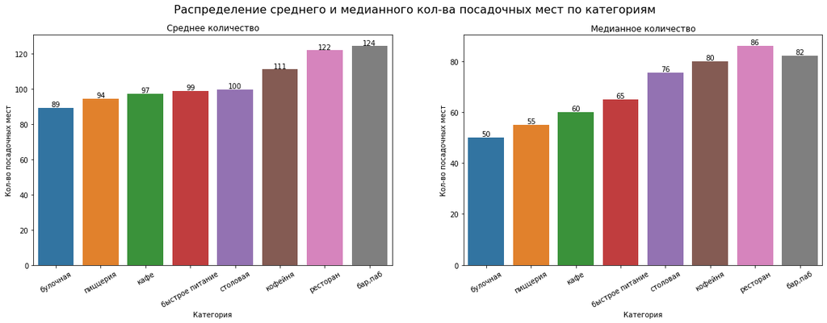

```python
# Строим график, добавляем необходимые настройки и выводим его

fig, ax = plt.subplots(ncols=2,figsize=(20,6))
fig.suptitle('Распределение среднего и медианного кол-ва посадочных мест по категориям', fontsize=16)


sns.barplot(x='category', y='mean_seats', data=groupby_seats, ax=ax[0])

for p in ax[0].patches:
    height = p.get_height()
    ax[0].text(p.get_x()+p.get_width()/2,
        height + 0.57,
        '{:.0f}'.format(height),
        fontsize=10,
        ha="center")

ax[0].set_title('Среднее количество')
ax[0].set_xlabel('Категория')
ax[0].set_ylabel('Кол-во посадочных мест')
ax[0].tick_params(axis='x', rotation=30)

sns.barplot(x='category', y='median_seats', data=groupby_seats, ax=ax[1])


for p in ax[1].patches:
    height = p.get_height()
    ax[1].text(p.get_x()+p.get_width()/2,
        height + 0.57,
        '{:.0f}'.format(height),
        fontsize=10,
        ha="center")

ax[1].set_title('Медианное количество')
ax[1].set_xlabel('Категория')
ax[1].set_ylabel('Кол-во посадочных мест')
ax[1].tick_params(axis='x', rotation=30)


plt.show()
```

**Вывод**

- Как по средним, так и медианным значениям лидерами по количеству посадоных мест явлются `кофейня`, `ресторан` и `бар, паб` - в среднем больше `111` посадочных мест;
- Меньше всего посадоных мест в заведениях типа `булочная`, `пиццерия` и `кафе`, в среднем от `89-97` мест.

## Исследуем соотношение сетевых и несетевых заведений

Рассмотрим соотношение сетевых и несетевых заведений в датасете

```python
# Подготовавливаем необходимые данные для графика

groupby_chain = (
    df.groupby('chain', as_index=False)
    .agg(object_num=('name', 'count'))
    .sort_values('object_num', ascending=False)
)
```

```python
# Строим график, добавляем необходмые настройки и выводим его

fig = go.Figure(data=[go.Pie(labels=groupby_chain['chain'],
                             values=groupby_chain['object_num'],
                             pull=[0.075])])

fig.update_layout(title='Доля сетевых и несетевых заведений')
fig.show()
```

[figure not shown]

**Вывод**

Изучим соотношение сетевых и несетевых заведений в разрезе их категорий. Для этого подготовим необходимые данные и построи графики.

```python
# Подготовавливаем необходимые данные для графика

groupby_chain_cat = df.groupby(['category', 'chain'],as_index=False).agg(num_of_chain=('name','count'))
groupby_chain_cat = (groupby_chain_cat.merge
                     (df.groupby('category',as_index=False)
                      .agg(total_of_cat=('name','count')),
                     how='left'))
groupby_chain_cat['chain_ratio'] = (groupby_chain_cat['num_of_chain']/groupby_chain_cat['total_of_cat'])*100
```

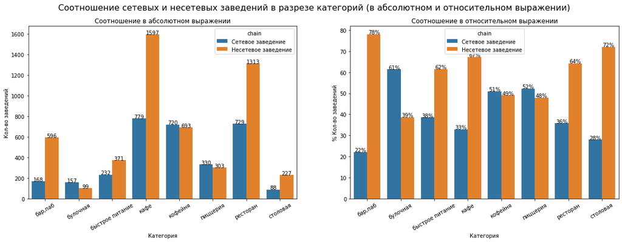

```python
# Строим график, добавляем необходмые настройки и выводим его

fig, ax = plt.subplots(ncols=2,figsize=(20,6))
fig.suptitle('Соотношение сетевых и несетевых заведений в разрезе категорий (в абсолютном и относительном выражении)', fontsize=16)

sns.barplot(x='category', y='num_of_chain', hue='chain', data=groupby_chain_cat, ax=ax[0])

# Подписываем каждый столбик
for p in ax[0].patches:
    height = p.get_height()
    ax[0].text(p.get_x()+p.get_width()/2,
        height + 0.57,
        '{:.0f}'.format(height),
        fontsize=10,
        ha="center")

ax[0].set_title('Соотношение в абсолютном выражении')
ax[0].set_xlabel('Категория')
ax[0].set_ylabel('Кол-во заведений')
ax[0].tick_params(axis='x', rotation=30)

sns.barplot(x='category', y='chain_ratio',hue='chain', data=groupby_chain_cat, ax=ax[1])

# Подписываем каждый столбик
for p in ax[1].patches:
    height = p.get_height()
    ax[1].text(p.get_x()+p.get_width()/2,
        height + 0.15,
        '{:.0f}%'.format(height),
        fontsize=10,
        ha="center")

ax[1].set_title('Соотношение в относительном выражении')
ax[1].set_xlabel('Категория')
ax[1].set_ylabel('% Кол-во заведений')
ax[1].tick_params(axis='x', rotation=30)


plt.show()
```

**Вывод**

- `Сетевые заведения` чаще всего преобладают в следующих категориях:
  1. `булочная` - **61%** заведений;
  2. `пиццерия` - **52%** заведений;
  3. `кофейня` - **51%** заведений.
- `Несетевые заведения` чаще всего преобладают в следующих категориях:
  1. `бар, паб` - **78%** заведений;
  2. `столовая` - **72%** заведений;
  3. `кафе` - **67%** заведений.

## Определяем топ-15 популярных сетей в Москве

```python
# Подготовавливаем необходимые данные для графика

chain_objects = (df.query('chain == "Cетевое заведение"')
                 .groupby('name',as_index=False)
                 .agg(object_num=('name','count'))
                 .sort_values(by='object_num',ascending=False)
                 .head(15)
                )
```

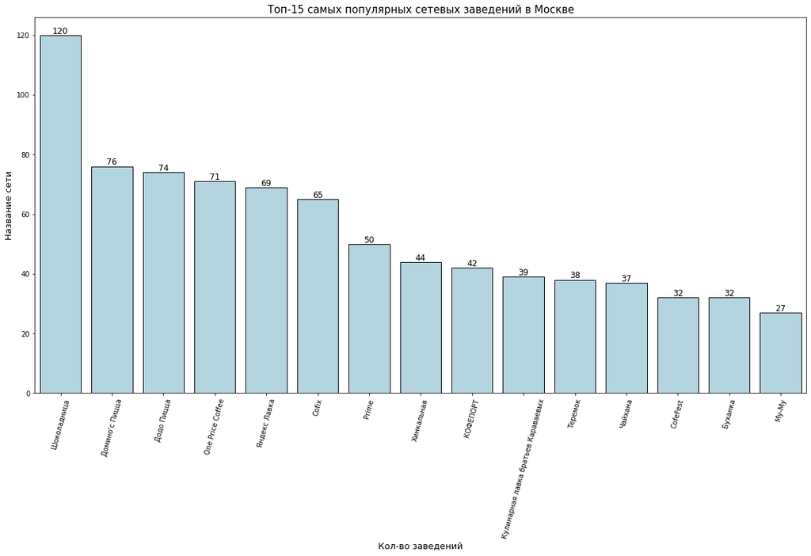

```python
# Строим график, добавляем необходмые настройки и выводим его

plt.figure(figsize=(20,10))

ax = sns.barplot(y='object_num', x='name', data=chain_objects, ec='black',color='lightblue')

for p in ax.patches:
    height = p.get_height()
    ax.text(p.get_x()+p.get_width()/2,
        height + 0.57,
        '{:.0f}'.format(height),
        fontsize=12,
        ha="center")


plt.title('Топ-15 самых популярных сетевых заведений в Москве',fontsize=15)
plt.xlabel('Кол-во заведений',fontsize=13)
plt.ylabel('Название сети',fontsize=13)
plt.xticks(rotation=75)

plt.show()
```

**Вывод**

- Первая тройка самый популярных сетевых заведений:
  1. `Шоколадница` - **120** заведений;
  2. `Домино'с Пицца` - **76** заведений;
  3. `Додо Пицца` - **74** заведений.
- Последняя тройка самый популярных сетевых заведений:
  1. `Му-Му` - **27** заведения;
  2. `CofeFest` и `Буханка` - по **32** заведения.

Рассмотрим какая категория заведения преобладает среди топ-15 сетевых объектов

```python
# Создаем список из названия топ-15 заведений
top15_lst = list(chain_objects['name'])

# Подготовавливаем необходимые данные для графика
df_filtered = df.query('name in @top15_lst')
top15_category = df_filtered['category'].value_counts().to_frame().reset_index()
top15_category.columns = ['category','object_num']
```

```python
# Строим график, добавляем необходмые настройки и выводим его

fig = go.Figure(data=[go.Pie(labels=top15_category['category'],
                             values=top15_category['object_num'],
                             pull=[0.075])])

fig.update_layout(title='Доля категорий в сетевых заведениях из списка топ-15')
fig.show()
```

[figure not shown]

**Вывод**

- Более **41%** (336 заведений) из топ-15 относятся к `кофейне`, далее идет `ресторан` - **23%** (186 заведений) и замыкает тройку `пиццерия` - **19%** (151 заведение);
- Чуть более **2%** (около 40 заведений) приходится на `булочную`, `бар, паб` и `столовую`

## Исследуем количество заведений в разрезе административных районов Москвы

```python
# Подготовавливаем необходимые данные для графика

groupby_district = (df.groupby('district', as_index=False)
                   .agg(object_num=('name','count'))
                   .sort_values(by='object_num', ascending=False))

district_category = (df.groupby(['district','category'], as_index=False)
                     .agg(object_num=('name','count'))
                     .sort_values(by='object_num')
                    )
```

```python
# Строим график, добавляем необходмые настройки и выводим его

fig=px.bar(district_category,
           x='object_num',
           y='district',
           color = 'category',
           orientation='h',
           title="Количество заведений каждой категории в разрезе административного района",
          labels={'district':'Админ. район',
                 'object_num':'Кол-во заведений'},
          width=1000,
          height=600)

fig.add_trace(go.Scatter(
                y=groupby_district['district'],
                x=groupby_district['object_num'],
                text=groupby_district['object_num'],
                mode='text',
                textposition='top right',
                textfont=dict(
                    size=9,
                ),
                showlegend=False
))

fig.show()
```

[figure not shown]

**Вывод**

- Больше всего заведений находится в:
  1. `ЦАО` - **2242**;
  2. `САО` - **898**;
  3. `ЗАО` - **850**.
- Меньше всего заведений находится в:
  1. `СЗАО` - **409**;
  2. `ЮВАО` - **714**;
  3. `ВАО` - **798**.
- В основом, во всех районах преобладают 3 категории: `кафе`, `ресторан` и `кофейня`, а меньше всего встречаются: `булочная`, `столовая` и `бар, паб`.

## Исследуем средние рейтинги по категориям заведений

```python
# Подготовавливаем необходимые данные для графика

cat_mean_rating = (df.groupby(['category'], as_index=False)
                  .agg(mean_rating=('rating','mean'))
                  .round(2)
                  .sort_values(by='mean_rating'))
```

```python
# Строим график, добавляем необходмые настройки и выводим его

fig = px.scatter(cat_mean_rating,
                 x='category',
                 y='mean_rating',
                 size='mean_rating',
                 color="category",size_max=50,
                labels={'mean_rating': 'Средний рейтинг',
                        'category': 'Тип заведения'},
                title='Средний рейтинг среди категории заведения', text='mean_rating',
                width=1100,
                height=500)

fig.update_layout(showlegend=False)

fig.show()
```

[figure not shown]

**Вывод**

- Средние рейтинги в разрезе категории объекта общественного питания находится примерно в одном, довольно хорошем уровне - от **4.05** у заведений `быстрого питания` до **4.39** баллов у `баров и пабов`.

## Строим фоновую картограмму средних рейтингов заведений каждого района Москвы

Для начала построим фоновую картограмму со средним рейтингом заведений каждого района. Для этого используем необходимый файл с данными, предварительно все подготовив и затем выведем полученную карту.

```python
# Читаем файл и сохраняем в переменной

with open('admin_level_geomap.geojson', 'r') as f:
    state_geo = json.load(f)
```

```python
# Подготовавливаем необходимые данные для карты
district_rating = df.groupby('district',as_index=False)['rating'].mean().round(2)
```

```python
# moscow_lat - широта центра Москвы, moscow_lng - долгота центра Москвы
moscow_lat, moscow_lng = 55.751244, 37.618423

# Создаём карту Москвы
m = Map(location=[moscow_lat, moscow_lng], zoom_start=10)

# Создаём хороплет с помощью конструктора Choropleth и добавляем его на карту
Choropleth(
    geo_data=state_geo,
    data=district_rating,
    columns=['district', 'rating'],
    key_on='feature.name',
    fill_color='YlGn',
    fill_opacity=0.8,
    legend_name='Средний рейтинг заведений по районам',
).add_to(m)

# Выводим карту
m
```

[figure not shown]

**Вывод**

В среднем, рейтинги по районам, как и в разрезе с категорией объекта общественного питания находятся на приличном большом уровне - от **4.1** в `ЮВАО` до **4.38** в `ЦАО`.

Теперь отобразим все заведения из датасета на карте с помощью кластеров.

```python
# moscow_lat - широта центра Москвы, moscow_lng - долгота центра Москвы
moscow_lat, moscow_lng = 55.751244, 37.618423

# Создаём карту Москвы
m = Map(location=[moscow_lat, moscow_lng], zoom_start=10)

# Создаём пустой кластер, добавляем его на карту
marker_cluster = MarkerCluster().add_to(m)

# Пишем функцию, которая принимает строку датафрейма,
# Создаёт маркер в текущей точке и добавляет его в кластер marker_cluster

def create_clusters(row):
    Marker(
        [row['lat'], row['lng']],
        popup=f"{row['name']} {row['rating']}",
    ).add_to(marker_cluster)

# Применяем функцию create_clusters() к каждой строке датафрейма
df.apply(create_clusters, axis=1)

# Выводим карту
m
```

[figure not shown]

Теперь в нашем распоряжении интерактивная карта с местоположением всех заведений и их рейтингами.

## Определяем топ-15 улиц по кол-ву заведений и улицы только с одним заведением

Проилюстрируем на графике топ-15 улиц по количеству заведений и их категорией

```python
# Создаем дф с топ-15 улицами по кол-ву заведений
top15_streets = (df.groupby('street', as_index=False)
                 .agg(object_num=('name','count'))
                 .sort_values(by='object_num', ascending=False)
                 .head(15)
                )

# Создаем список с этими улицами
top15_str_lst = list(top15_streets['street'])

# Готовим данные для графика
top15_streets_cat = (df.query('street in @top15_str_lst').groupby(['street','category'], as_index=False)
                     .agg(object_num=('name','count'))
                     .sort_values(by='object_num', ascending=False)
                    )
```

```python
# Строим график, добавляем необходмые настройки и выводим его

fig = px.bar(top15_streets_cat,
            y='street',
            x='object_num',
            color='category',
            orientation = 'h',
            labels={'street':'Улица', 'object_num':'Кол-во заведений'},
            title='Топ-15 улиц по количеству заведений в разрезе категорий объектов',
            width=1000,
            height = 650)

fig.add_trace(go.Scatter(
                 y=top15_streets['street'],
                 x=top15_streets['object_num'],
                 text=top15_streets['object_num'],
                 mode='text',
                 textposition='top right',
                 textfont=dict(
                     size=11,
                 ),
                 showlegend=False
))
fig.show()
```

[figure not shown]

**Вывод**

- Больше всего заведений находится на:
  1. `Проспекте Мира` - **183**;
  2. `Профсоюзная улица` - **122**;
  3. `Проспект Вернадского` - **108**.
- Меньше всего заведений находится на:
  1. `Алтуфьевском шоссе` - **47**;
  2. `Улице Пятницкая` - **48**;
  3. `Улице Миклухо-Маклая` - **49**.
- В основом, на всех улицах, как и в районах преобладают 3 категории: `кафе`, `ресторан` и `кофейня`, а меньше всего встречаются: `булочная`, `столовая` и `бар, паб`.

Теперь найдем улицы, на которых находится только один объект общепита. Для начала посчтитаем общее кол-во таких объектов.

```python
# Подготовавливаем необходимые данные
one_object_streets = (df.groupby(['street'],as_index=False)
                      .agg(object_num=('name','count'))
                      .query('object_num == 1')
                     )
# Выводим результат
print('Общее кол-во улиц с одним заведением:', len(one_object_streets))
```

```
Общее кол-во улиц с одним заведением: 485
```

Подготовим данные и посмотрим к каким категориям заведений чаще всего относятся данные объекты

```python
# Создадим список с улицами, где всего 1 объект общественного питания
one_object_streets_lst = list(one_object_streets['street'])

# Подготовавливаем необходимые данные для графика
one_object_streets_cat = (df.query('street in @one_object_streets_lst')
                            .groupby('category',as_index=False)
                            .agg(object_num=('name','count'))
                            .sort_values(by='object_num', ascending = False))
```

```python
# Строим график, добавляем необходмые настройки и выводим его

fig = go.Figure(data=[go.Pie(labels=one_object_streets_cat['category'],
                             values=one_object_streets_cat['object_num'],
                             pull=[0.075])])

fig.update_layout(title='Доля категории объекта в разрезе улиц с одним заведением')
fig.show()
```

[figure not shown]

**Вывод**

- В основом, на улицах с одним объектом преобладают:
  1. `кафе` - **36%** заведений;
  2. `ресторан` - **20%** заведений;
  3. `кофейня` - **19%** заведений.

И дополнительно рассмотрим в каких районах больше всего улиц с одним заведением

```python
# Подготовавливаем необходимые данные для графика

one_object_streets_distr = (df.query('street in @one_object_streets_lst')
                              .groupby('district',as_index=False)
                              .agg(object_num=('name','count'))
                              .sort_values(by='object_num', ascending = False))
```

```python
# Строим график, добавляем необходмые настройки и выводим его

fig = go.Figure(data=[go.Pie(labels=one_object_streets_distr['district'],
                             values=one_object_streets_distr['object_num'],
                             pull=[0.075])])

fig.update_layout(title='Доля улиц с одним заведением в разрезе административного района объекта')
fig.show()
```

[figure not shown]

**Вывод**

- Больше всего улиц с одним заведением находится в:
  1. `ЦАО` - **30%**;
  2. `ВАО` и `СВАО` - около **12%**.
- Меньше всего улиц с одним заведением находится в:
  1. `ЮЗАО` и `СЗАО` - около **4%**;
  2. `ЮВАО` - **9%**.

## Строим фоновую картограмму средних чеков в заведениях для каждого района

Для того, чтобы посторить картограмму средних чеков, нам нужно посчтитать медианнон значение средних чеков по каждому району и после этого отобразить полученный рез-т на карте

```python
# Подготовавливаем необходимые данные для карты

distr_median_price = (df.groupby('district',as_index=False)
                      .agg(median_price=('middle_avg_bill','median'))
                      .round(2)
                      .sort_values(by='median_price',ascending=False)
                     )
```

```python
# moscow_lat - широта центра Москвы, moscow_lng - долгота центра Москвы
moscow_lat, moscow_lng = 55.751244, 37.618423

# Создаём карту Москвы
m = Map(location=[moscow_lat, moscow_lng], zoom_start=10)

# Создаём хороплет с помощью конструктора Choropleth и добавляем его на карту
Choropleth(
    geo_data=state_geo,
    data=distr_median_price,
    columns=['district', 'median_price'],
    key_on='feature.name',
    fill_color='YlGn',
    fill_opacity=0.8,
    legend_name='Средний чек в заведениях по районам',
).add_to(m)

# Выводим карту
m
```

[figure not shown]

**Вывод**

- Самым высокий средний чек в заведениях находится в `ЦАО` и `ЗАО` - **1000 руб.**
- Самый низкий средний чек в заведениях находится в `ЮВАО`, `ЮАО` и `СВАО` - **450-500 руб.**
- Мы наблюдаем закономерность в снижении среднего чека в зависимости от удаленности от центра (за исключением `ЗАО`)

# Исследование рынка кофеен

## Изучаем данные по количеству кофеен

```python
# Смотрим сколько кофеен в датасете

coffee_df = df.query('category == "кофейня"')
print('Всего кофеен в датасете:',len(coffee_df))
```

```
Всего кофеен в датасете: 1413
```

Теперь рассмотрим распределение кофеен по административным округам. Подготовим даннные и выведем график.

```python
# Подготовавливаем необходимые данные для графика

coffee_distr = (coffee_df.groupby('district',as_index=False)
                .agg(object_num=('name','count'))
                .sort_values(by='object_num',ascending=False)
               )
```

```python
# Строим график, добавляем необходмые настройки и выводим его

fig = go.Figure(data=[go.Pie(labels=coffee_distr['district'],
                             values=coffee_distr['object_num'],
                             pull=[0.075])])

fig.update_layout(title='Распределение кофеен в разрезе административных округов')
fig.show()
```

[figure not shown]

**Вывод**

- Больше всего кофеен в:
  1. `ЦАО` - **30%**;
  2. `САО` - **14%**;
  3. `СВАО` - **11%**.
- Меньше всего кофеен в:
  1. `СЗАО` - **4%**;
  2. `ЮВАО` - **6%**;
  3. `ЮЗАО` - **7%**.

## Изучаем время работы кофеен

Рассмотрим соотношение кофеен по времени работы.

```python
# Подготовавливаем необходимые данные для графика

coffee_working_hours = (coffee_df['is_24/7']
                        .value_counts()
                        .to_frame()
                        .reset_index()
                        .replace({'index':{False:'Не круглосуточный',True:'Круглосуточный'}})
                        .rename(columns={'index':'working_hours','is_24/7':'amount'})
                        )
```

```python
# Строим график, добавляем необходмые настройки и выводим его

fig = go.Figure(data=[go.Pie(labels=coffee_working_hours['working_hours'],
                             values=coffee_working_hours['amount'],
                             pull=[0.2],
                             rotation=90)])

fig.update_layout(title='Соотношение кофеен в разрезе времени работы')
fig.show()
```

[figure not shown]

**Вывод**

- Подавляющее большинство кофеен не круглосуточные - **96%**, круглосуточных всего **4%**.

Рассмотрим соотношение кофеен по времени работы в разрезе типа объекта

```python
# Подготовавливаем необходимые данные для графика

around_the_clock_obj_ratio = (coffee_df.pivot_table
                              (index='chain',
                               columns='is_24/7',
                               values='name',
                               aggfunc=('count'))
                              .reset_index())

around_the_clock_obj_ratio.columns = ['chain','not_24/7','is_24/7']
```

```python
# Строим график, добавляем необходмые настройки и выводим его

fig = make_subplots(rows=1,
                    cols=2,
                    specs=[[{'type':'domain'}, {'type':'domain'}]],
                    subplot_titles=("Не круглосуточные кофейни", "Круглосуточные кофейни"))

fig.add_trace(go.Pie(labels=around_the_clock_obj_ratio['chain'], values=around_the_clock_obj_ratio['not_24/7'],pull=[0.05]),
              1, 1)
fig.add_trace(go.Pie(labels=around_the_clock_obj_ratio['chain'], values=around_the_clock_obj_ratio['is_24/7'], pull=[0.075]),
              1, 2)

fig.update_layout(title_text='Соотношение кофеен по типу объекта в разрезе времени работы')

fig.show()
```

[figure not shown]

**Вывод**

- Сетевые и несетевые кофейни практически поровну работает не круглосуточно
- Подавляющее большинство круглосуточных кофеен - сетеевые (**85%**) и только **15%** из них несетевые.

При открытии кофейни целесообразней выбрать не круглосуточный формат работы, так основная аудитория таких заведений посещает их в дневное/вечернее рабочее время.

## Изучаем рейтинги кофеен

```python
# Подготовавливаем необходимые данные для графика

coffee_distr_rating = (coffee_df.groupby(['district'], as_index=False)
                  .agg(mean_rating=('rating','mean'))
                  .round(2)
                  .sort_values(by='mean_rating'))
```

```python
# Строим график, добавляем необходмые настройки и выводим его

fig = px.scatter(coffee_distr_rating,
                 x='district',
                 y='mean_rating',
                 size='mean_rating',
                 color='district',size_max=50,
                labels={'mean_rating': 'Средний рейтинг',
                        'district': 'Административный район'},
                title='Средний рейтинг кофеен по административным районам', text='mean_rating',
                width=1100,
                height=600)

fig.update_layout(showlegend=False)
fig.update_xaxes(tickangle=-45)

fig.show()
```

[figure not shown]

**Вывод**

- Средние рейтинги кофеен в разрезе адммнистративного района находится примерно на одном, достаточно высоком уровне - от **4.2** у `ЗАО` до **4.34** баллов у `ЦАО`.

## Изучаем стоимость чашки капучино в кофейнях

Для начала изучим медианную стоимость чашки капучино по всей Москве (из того небольшого кол-ва данных по этому параметру, которые у нас имеются)

```python
print("Медианная цена чашки капучино по Москве:", coffee_df['middle_coffee_cup'].median())
```

```
Медианная цена чашки капучино по Москве: 170.0
```

Теперь посмотрим на нее в разрезе административных округов

```python
# Подготовавливаем необходимые данные для графика

coffee_median_cup_price = (coffee_df.groupby('district',as_index=False)
                      .agg(median_price=('middle_coffee_cup','median'))
                      .round(2)
                      .sort_values(by='median_price',ascending=False)
                   )
```

```python
# moscow_lat - широта центра Москвы, moscow_lng - долгота центра Москвы
moscow_lat, moscow_lng = 55.751244, 37.618423

# Создаём карту Москвы
m = Map(location=[moscow_lat, moscow_lng], zoom_start=10)

# Создаём хороплет с помощью конструктора Choropleth и добавляем его на карту
Choropleth(
    geo_data=state_geo,
    data=coffee_median_cup_price,
    columns=['district', 'median_price'],
    key_on='feature.name',
    fill_color='YlGn',
    fill_opacity=0.8,
    legend_name='Медианная цена чашки капучино в разрезе округа',
).add_to(m)

# Выводим карту
m
```

[figure not shown]

**Вывод**

- Самым высокий медианный чек в заведениях находится в `ЮЗАО` - **198 руб.** далее идут `ЦАО`и `ЗАО` - около **190 руб.**
- Самый низкий медианный чек в заведениях находится в `ВАО` - **135 руб.** далее идут `ЮВАО` и `ЮАО` - около **150 руб.**

## Изучаем среднее кол-во посадочных мест по округам

```python
# Подготовавливаем необходимые данные для графика

coffee_seats = (coffee_df.groupby('district')
                .agg(mean_seats=('seats','mean'))
                .astype(int)
                .reset_index()
                .sort_values(by='mean_seats')
               )
```

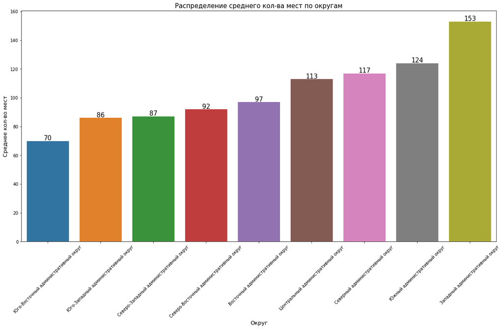

```python
# Строим график, добавляем необходмые настройки и выводим его

plt.figure(figsize=(20,10))
ax = sns.barplot(x='district', y='mean_seats', data=coffee_seats)

for p in ax.patches:
    height = p.get_height()
    ax.text(p.get_x()+p.get_width()/2,
        height + 0.57,
        '{:.0f}'.format(height),
        fontsize=15,
        ha="center")


plt.title('Распределение среднего кол-ва мест по округам',fontsize=15)
plt.xlabel('Округ',fontsize=13)
plt.ylabel('Среднее кол-во мест',fontsize=13)
plt.xticks(rotation=45)

plt.show()
```

**Вывод**

- Меньше всего посадочных мест в `ЮВАО` - **70**, `ЮЗАО` и `СЗАО` практически одинаково - **86-87**
- Больше всего посадочных мест `ЗАО` - **153** , `ЮАО` - **124** и `САО`- **117**

## Вывод по разделу и рекомендации

**Вывод:**

- Всего кофеен в предоставленном нам датасете - **1413**. Больше всего их в `ЦАО` - **30%** и `САО` - **14%**, а меньше в `СЗАО` - **4%** и `ЮЗАО` - **7%**;
- **96%** кофеен работают не круглосуточно, в то же время **85%** круглосуточных кофеен - сетевые;
- Средние рейтинги кофеен в разрезе адммнистративного окргуа примерно на одном уровне и составляют от **4.2** до **4.34** баллов;
- Самая высокая медианная стоимость чашки капучино в заведениях находится в `ЮЗАО` - **198 руб.** далее идут `ЦАО`и `ЗАО` - около **190 руб.**, ниже всего в `ВАО` - **135 руб.**
- Среди всех округов, наименьшее среднее кол-во посадочных мест в `ЮВАО` - **70**, наибольшее в `ЗАО` - **153**

**Рекомендации:**

После проведенного исследования можно сформулировать следующие рекомендации для открытия кофейни:

1. Место - `Юго-Западный административный округ`, так как там находится одно из наименьших количеств кофеен - **7%** (96 объектов), что дает нам возможность для большей конкурентоспособности по сравнению с другими округами, где кофеен гораздо больше;
1. Предпочтительно выбрать режим работы не круглосуточный (как вариант - ежеденво с 10:00 - 22:00), так как круглосуточный формат, в основном представлен в **85%** случаях только в сетевых кофейнях, мы же, на первоначальном этапе ограничиваемся только одним заведеним;
1. Рейтинг кофеен в данном округе на довольно высоком уровне - **4.28 балла**, практически ничем не уступает самому высокооцененному округу `ЦАО` - **4.34 балла**;
1. Также в пользу `ЮЗАО` можно выделить самую высокую медианную стоимость чашки капучино в **198 руб**, что дает нам потеницальную возможность заработать больше, снизив на первоначальном этапе цены на `10-15%` по сравнению с конкурентами в этом районе;
1. На первоначальном этапе по количеству посадочных мест будет достаточно ограничиться в **90**.

# Вывод

Мы провели исследование рынка заведений общественного питания Москвы. В ходе исследования мы решилими поставленные перед нами задачи:

- Провели первчиную подготовку и предобработку данных, устранив все недочеты, и приведя данные датафрейма к пригодному для проведения анализа виду;
- Выполнили непосредственный анализ рынка, ответив на все поставленные вопросы от инвесторов и дали необходимые рекомендации для открытия кофейни.